# Group A: Wine Reviews

Yaxin Deng, Xiaomeng Huang, Anderson Nelson, Min Sun

April 25 2019

# Introduction

- **Country:** The country that the wine is from
- **Designation:** The vineyard within the winery where the grapes that made the wine are from
- **Points:** The number of points WineEnthusiast rated the wine on a scale of 1-100
- **Price:** The cost for a bottle of the wine
- **Province:** The province or state that the wine is from
- **Region_1:** The wine growing area in a province or state (ie Napa)
- **Region_2:** Sometimes there are more specific regions specified within a wine growing area (ie Rutherford inside the Napa Valley), but this value can sometimes be blank
- **Taster_name**
- **Taster_twitter_handle**
- **Title:** The title of the wine review, which often contains the vintage if you’re interested in extracting that feature
- **Variety:** The type of grapes used to make the wine (ie Pinot Noir)
- **Winery:** The winery that made the wine

# Project Goals and Deliverables

- What are the factors that influence prices?
- Create a recommendation system that that utilizes historical data from the reviwer to recommend wines that they are likely to enjoy
- Extract insights from the reviews using NLP techniques
  - Discover the abstract “topics” that occur in the user reviews
  - Classify the wine based on description of flavor
- Create a model that predicts price and point and evaluate on a test using RMSE and accuracy respectively?
- Quantify the impact of wine description on price and point?
  - Hypothesis: user description is signficant in predicting points, and not significant when predicting price?

# Exploratory Data Analysis

The con for this approach is that the dataset has a wide distribution and may not accurately reflect the best cluster for, however each quantile has an equal amount of numeric values.

To improve this analysis we are considering a cluster analysis to evaluate the categories.

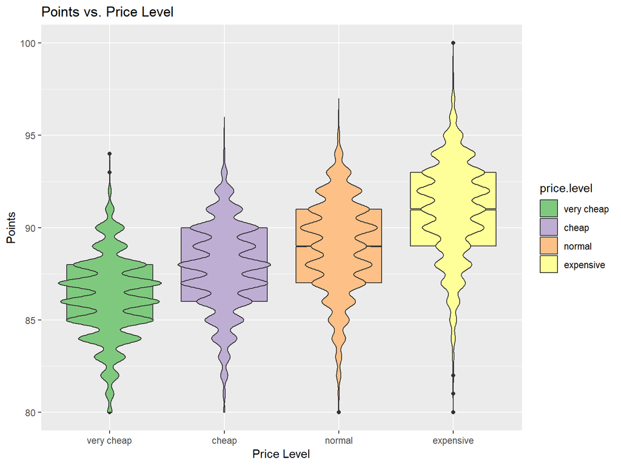

```
## breaks
##    4   17   25   42 3300
##    1    1    1    1    1
```

# Visualization and Insight:

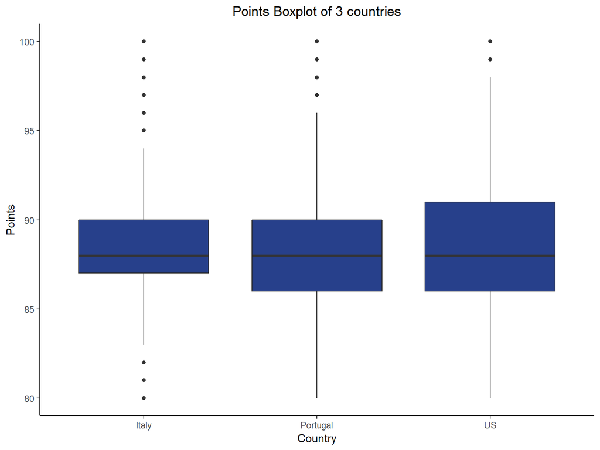

# Text Analytics

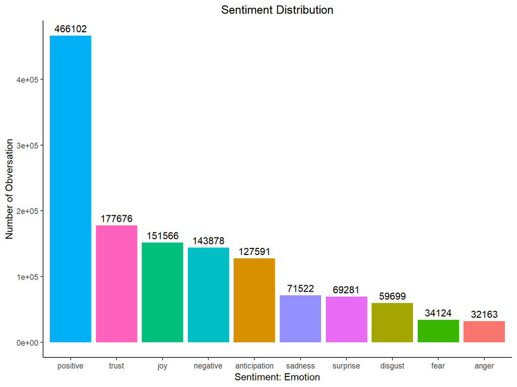

# Sentimenent Analysis by country

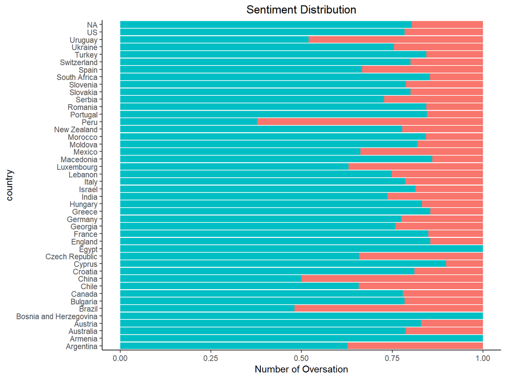

# Text analytics

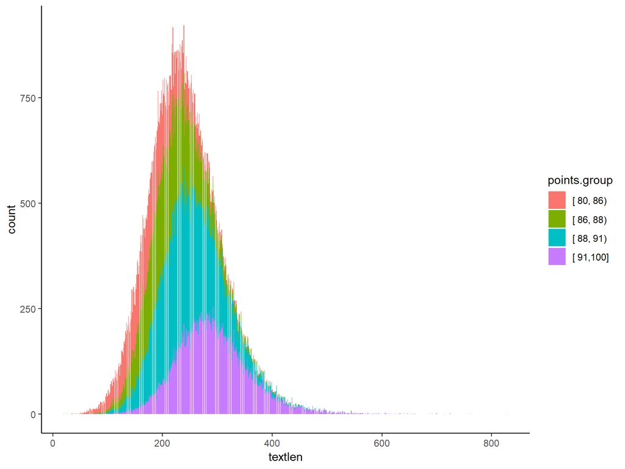

# Text Analysis

- Step 2: Data Pipeline

  > Tokenization Remove “stopwords” Stem the words Create a document-feature matrix

```r
# cut reviews into single words
text.tokens=tokens(textdat$description,what="word",remove_numbers=TRUE, remove_punct=TRUE,remove_symbols = TRUE, remove_hyphens = TRUE)
# remove unwanted words
text.tokens=tokens_select(text.tokens,stopwords(),selection = "remove" )
# word stem
text.tokens=tokens_wordstem(text.tokens,language = "english")
# Create dfm
text.tokens.dfm <- dfm(text.tokens, tolower = FALSE)
```

# Text Analysis

- Step 3: WordCloud

[interactive chart not shown]

# Text Analysis

- Step 4: Term Frequency-Inverse Document Frequency (TF-IDF)

TF-IDF is a powerful technique for enhancing the information/signal contained within our document-frequency matrix.

> Normalize all documents in the corpus to be length independent Penalize terms occur frequency across corpus

Based on wordcloud plot, we selected top 100 frequetent words. Then we delected some meaningless words, such as “wine”,“well”,“show” and etc. In the end, we chose 58 words as our new variables.

|  | text1 | text2 | text3 | text4 | text5 | text6 |
| --- | --- | --- | --- | --- | --- | --- |
| fruit | 0.05 | 0.04 | 0 | 0 | 0 | 0.03 |
| acid | 0.07 | 0.06 | 0.13 | 0 | 0 | 0.04 |
| palat | 0.07 | 0 | 0 | 0.13 | 0 | 0 |
| aroma | 0 | 0 | 0 | 0.14 | 0 | 0.05 |
| cherri | 0 | 0 | 0 | 0 | 0 | 0 |
| tannin | 0 | 0.07 | 0 | 0 | 0 | 0 |
| ripe | 0 | 0.08 | 0 | 0 | 0 | 0 |
| dri | 0.19 | 0 | 0 | 0 | 0 | 0 |
| spice | 0 | 0 | 0 | 0 | 0 | 0 |
| rich | 0 | 0 | 0 | 0 | 0 | 0 |

# Text Analysis

- Step 5: Prediction

```
##
## Call:
## lm(formula = the.formula, data = train)
##
## Residuals:
##    Min     1Q Median     3Q    Max
## -8.874 -1.854 -0.140  1.780 12.432
##
## Coefficients:
##               Estimate Std. Error  t value Pr(>|t|)
## (Intercept) 86.4099542  0.0254242 3398.723  < 2e-16 ***
## fruit        0.2640120  0.0151283   17.452  < 2e-16 ***
## acid        -0.0400647  0.0194388   -2.061 0.039300 *
## palat        0.3704473  0.0206199   17.966  < 2e-16 ***
## aroma       -0.2910348  0.0208589  -13.953  < 2e-16 ***
## cherri       0.3774340  0.0204977   18.414  < 2e-16 ***
## tannin       0.3584943  0.0223504   16.040  < 2e-16 ***
## ripe         0.4696784  0.0209837   22.383  < 2e-16 ***
## dri         -0.0169743  0.0209821   -0.809 0.418524
## spice        0.6300602  0.0223136   28.237  < 2e-16 ***
## rich         1.0225065  0.0233561   43.779  < 2e-16 ***
## fresh        0.4115896  0.0226023   18.210  < 2e-16 ***
## berri       -0.0438222  0.0243092   -1.803 0.071438 .
## oak          0.1788159  0.0240215    7.444 9.85e-14 ***
## plum         0.1487790  0.0259966    5.723 1.05e-08 ***
## textur       0.5691638  0.0274191   20.758  < 2e-16 ***
## sweet       -0.3671648  0.0257637  -14.251  < 2e-16 ***
## appl         0.1667970  0.0275744    6.049 1.46e-09 ***
## full         0.4362892  0.0296697   14.705  < 2e-16 ***
## blend        0.1334681  0.0287369    4.644 3.41e-06 ***
## balanc       0.9114846  0.0277349   32.864  < 2e-16 ***
## bodi         0.1731679  0.0309473    5.596 2.21e-08 ***
## blackberri   0.5523660  0.0286621   19.272  < 2e-16 ***
## light       -0.1867220  0.0267636   -6.977 3.04e-12 ***
## soft        -0.4495091  0.0286155  -15.709  < 2e-16 ***
## age          1.0493993  0.0291566   35.992  < 2e-16 ***
## structur     0.9349625  0.0300833   31.079  < 2e-16 ***
## white        0.1447356  0.0287799    5.029 4.94e-07 ***
## crisp       -0.1424896  0.0306993   -4.641 3.46e-06 ***
## fruiti      -0.5931644  0.0307583  -19.285  < 2e-16 ***
```

[output cut: 20 more lines]

```
## spici        0.4509258  0.0382417   11.791  < 2e-16 ***
## wood        -0.1324879  0.0385437   -3.437 0.000588 ***
## lime         0.3780611  0.0405496    9.323  < 2e-16 ***
## intens       1.2865980  0.0406353   31.662  < 2e-16 ***
## tart        -0.0145694  0.0406691   -0.358 0.720162
## tannic      -0.0004847  0.0413466   -0.012 0.990647
## tight        0.6992935  0.0409665   17.070  < 2e-16 ***
## herbal      -0.3632541  0.0388307   -9.355  < 2e-16 ***
## orang        0.4533096  0.0403955   11.222  < 2e-16 ***
## ---
## Signif. codes:  0 '***' 0.001 '**' 0.01 '*' 0.05 '.' 0.1 ' ' 1
##
## Residual standard error: 2.661 on 90922 degrees of freedom
## Multiple R-squared:  0.235,  Adjusted R-squared:  0.2345
## F-statistic: 481.5 on 58 and 90922 DF,  p-value: < 2.2e-16
```

# Text Analysis

- Step 5: Prediction(cont’d)

If we allow a samll difference between actual points and estimated points (eg:abs(diff)=2), the accuracy rate is 54.22%.

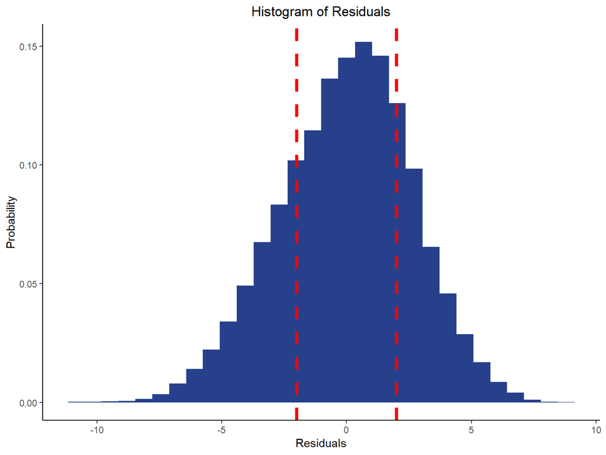

# Building a recommendation system

Since, users tend to vary in their pattern of evaluation (positivity bias, negativity bias, consistent ratings), it is a good practice to standardize data (center, Z-score)

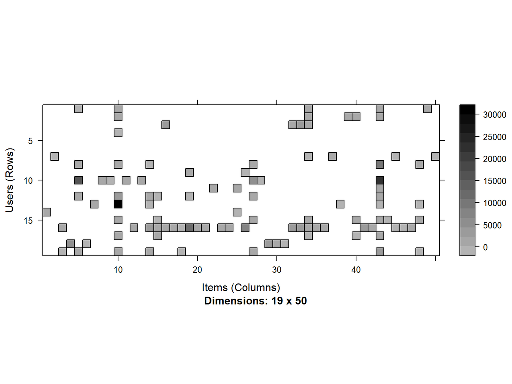

```r
dat <- dat %>%
 select(taster_name, variety,points)

dat <- dat[complete.cases(dat)]

# convert into a s4 class
data_matrix <- as(dat, 'realRatingMatrix')
image(data_matrix[1:19,1:50])
```

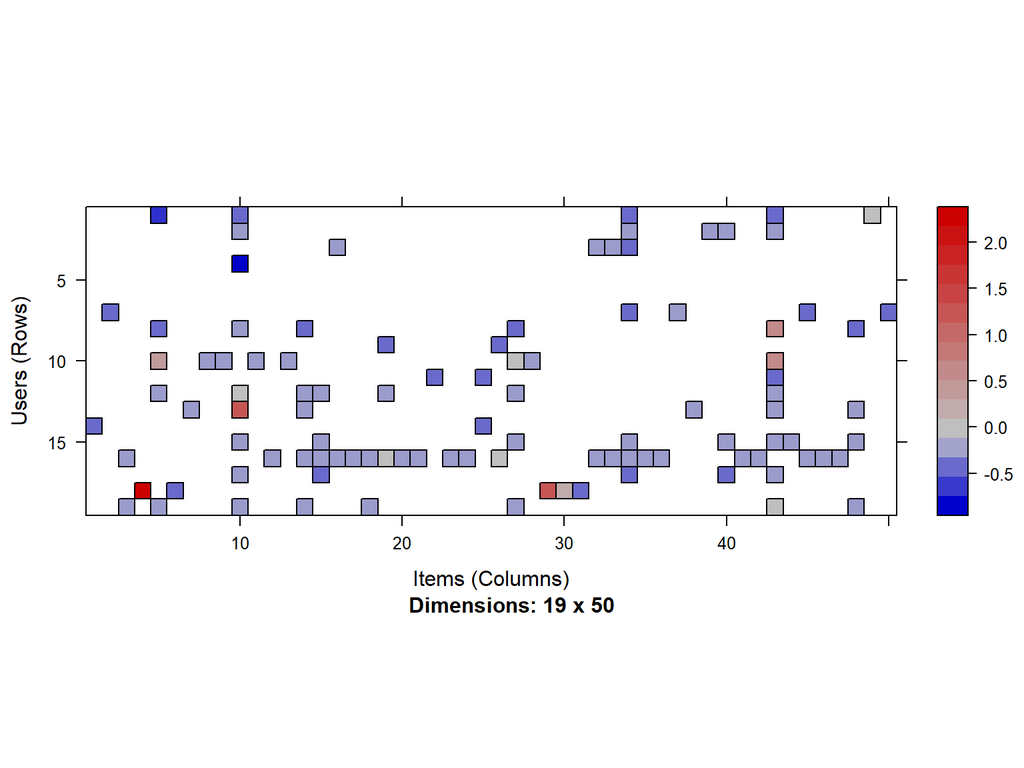

```r
# z score normalization
data_matrix_znorm <-normalize(x = data_matrix, method='Z-score')
image(data_matrix_znorm[1:19,1:50])
```

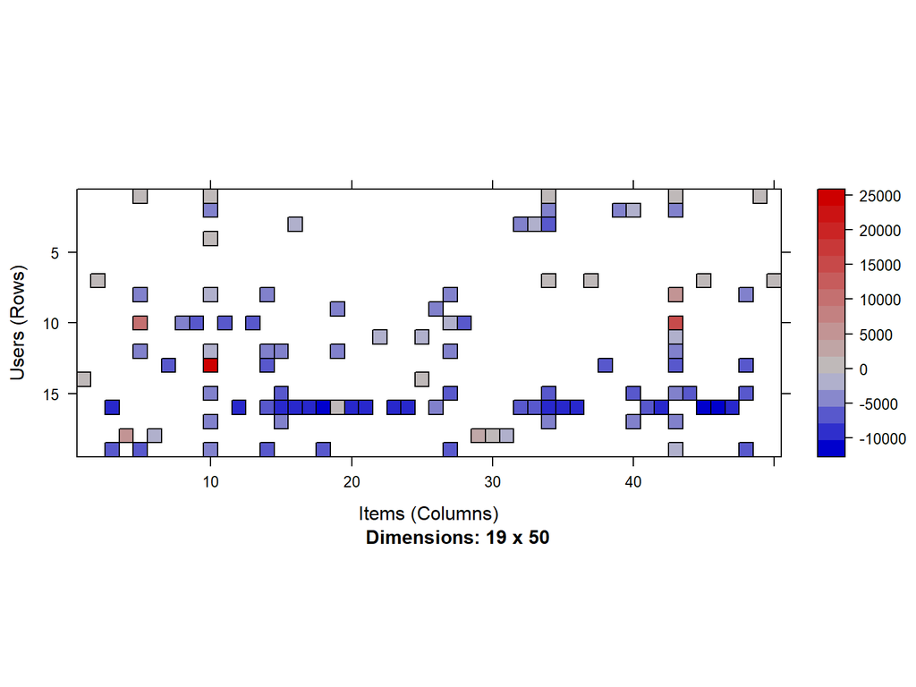

```r
# center normalization
data_matrix_cnorm <-normalize(x = data_matrix, method='center')
image(data_matrix_cnorm[1:19,1:50])
```

# Building a recommendation system: Generating Predictions, normal data set

Generating top 2 movie recommendations uding the popular method on the unmodified dataset.

```
## Recommender method: POPULAR for realRatingMatrix
## Description: Recommender based on item popularity.
## Reference: NA
## Parameters:
##   normalize
## 1  "center"
##                                                      aggregationRatings
## 1 new("standardGeneric", .Data = function (x, na.rm = FALSE, dims = 1,
##                                                   aggregationPopularity
## 1 new("standardGeneric", .Data = function (x, na.rm = FALSE, dims = 1,
```

|  | Alexander Peartree | Anna Lee C. Iijima | Anne KrebiehlÂ MW | Carrie Dykes | Christina Pickard | Fiona Adams | Jeff Jenssen | Jim Gordon | Joe Czerwinski | Kerin Oâ€™Keefe | Lauren Buzzeo | Matt Kettmann | Michael Schachner | Mike DeSimone | Paul Gregutt | Roger Voss | Sean P. Sullivan | Susan Kostrzewa | Virginie Boone |
| --- | --- | --- | --- | --- | --- | --- | --- | --- | --- | --- | --- | --- | --- | --- | --- | --- | --- | --- | --- |
| 1 | Portuguese Red | Portuguese Red | Bordeaux-style Red Blend | Pinot Noir | Red Blend | Pinot Noir | Portuguese Red | Portuguese Red | Nebbiolo | Pinot Noir | Nebbiolo | Portuguese Red | Portuguese Red | Malbec | Portuguese Red | Nebbiolo | Portuguese Red | Malbec | Portuguese Red |
| 2 | Zinfandel | Nebbiolo | Malbec | Syrah | Bordeaux-style Red Blend | Riesling | Nebbiolo | Portuguese White | Portuguese White | Bordeaux-style Red Blend | Sangiovese | Portuguese White | Zinfandel | Portuguese Red | Portuguese White | Tempranillo | Champagne Blend | Portuguese Red | Champagne Blend |

# Building a recommendation system: Generating Predictions, normalized data set

Generating top 2 movie recommendations uding the popular method on the normalize dataset.

|  | Alexander Peartree | Anna Lee C. Iijima | Anne KrebiehlÂ MW | Carrie Dykes | Christina Pickard | Fiona Adams | Jeff Jenssen | Jim Gordon | Joe Czerwinski | Kerin Oâ€™Keefe | Lauren Buzzeo | Matt Kettmann | Michael Schachner | Mike DeSimone | Paul Gregutt | Roger Voss | Sean P. Sullivan | Susan Kostrzewa | Virginie Boone |
| --- | --- | --- | --- | --- | --- | --- | --- | --- | --- | --- | --- | --- | --- | --- | --- | --- | --- | --- | --- |
| 1 | Portuguese Red | Portuguese Red | Bordeaux-style Red Blend | Pinot Noir | Red Blend | Pinot Noir | Portuguese Red | Portuguese Red | Nebbiolo | Pinot Noir | Nebbiolo | Portuguese Red | Portuguese Red | Malbec | Portuguese Red | Nebbiolo | Portuguese Red | Malbec | Portuguese Red |
| 2 | Zinfandel | Nebbiolo | Malbec | Syrah | Bordeaux-style Red Blend | Riesling | Nebbiolo | Portuguese White | Portuguese White | Bordeaux-style Red Blend | Sangiovese | Portuguese White | Zinfandel | Portuguese Red | Portuguese White | Tempranillo | Champagne Blend | Portuguese Red | Champagne Blend |

# Building a recommendation system: Generating Predictions, z score data set data set

Generating top 2 movie recommendations uding the popular method on the dataset scaled using the Z score.

|  | Alexander Peartree | Anna Lee C. Iijima | Anne KrebiehlÂ MW | Carrie Dykes | Christina Pickard | Fiona Adams | Jeff Jenssen | Jim Gordon | Joe Czerwinski | Kerin Oâ€™Keefe | Lauren Buzzeo | Matt Kettmann | Michael Schachner | Mike DeSimone | Paul Gregutt | Roger Voss | Sean P. Sullivan | Susan Kostrzewa | Virginie Boone |
| --- | --- | --- | --- | --- | --- | --- | --- | --- | --- | --- | --- | --- | --- | --- | --- | --- | --- | --- | --- |
| 1 | Portuguese Red | Portuguese Red | Bordeaux-style Red Blend | Pinot Noir | Red Blend | Pinot Noir | Portuguese Red | Portuguese Red | Nebbiolo | Pinot Noir | Nebbiolo | Portuguese Red | Portuguese Red | Malbec | Portuguese Red | Nebbiolo | Portuguese Red | Malbec | Portuguese Red |
| 2 | Zinfandel | Nebbiolo | Malbec | Syrah | Bordeaux-style Red Blend | Riesling | Nebbiolo | Portuguese White | Portuguese White | Bordeaux-style Red Blend | Sangiovese | Portuguese White | Zinfandel | Portuguese Red | Portuguese White | Tempranillo | Champagne Blend | Portuguese Red | Champagne Blend |

# Conclusion: